# Project 2: Data Mining, Classification, Prediction

SDS322E

# Mining, Classification, Prediction

## Louise Mendoza, lam5836

### Introduction

The dataset I selected is called “VA” and is a dataset that is based off a Veteran’s Lung Cancer Trial done by Kabfleisch and Prentice. The variables of this dataset are: ‘stime’ (survival time in days since treatment), ‘status’ (the status of a patient as dead (1) or alive (0)), ‘treat’ (type of lung cancer treatment where (1) is standard and (2) is the test drug), ‘age’ (patient’s age in years), ‘Karn’ (Karnofsky score of patient’s performance on a scale of 0 to 100), ‘diag.time’ (time since diagnosis in months), ‘cell’ (one of the four cell types where (1) is squamous, (2) is small cell, (3) is adeno, and (4) is large), and ‘prior’ (prior therapy where (0) is none and (10) is yes). I found the data in the MASS package. There are 137 observations with 8 variables. For my binary variable, ‘treat’, there are 69 observations that received standard treatment (1) and 68 observations that received the test-drug (2).

```r
library(tidyverse)
library(dplyr)
VA <- MASS::VA
VA %>% group_by(treat) %>% summarize(n = n())
```

```
## # A tibble: 2 x 2
##   treat     n
##   <fct> <int>
## 1 1        69
## 2 2        68
```

### Cluster Analysis

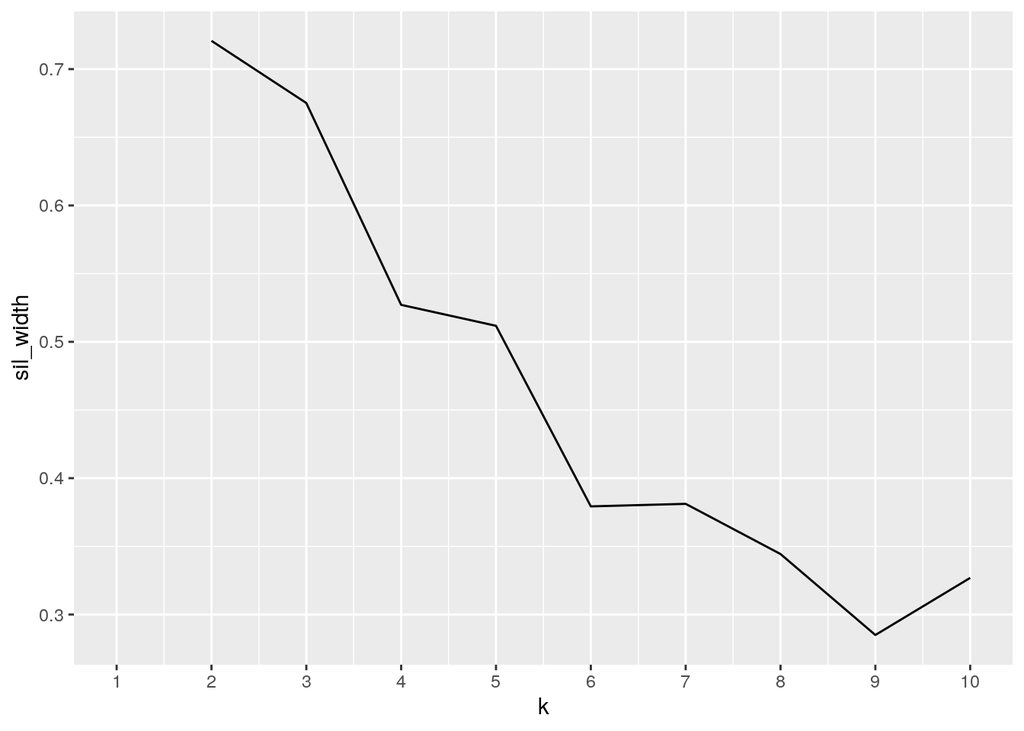

```r
library(cluster)
library(ggplot2)
library(GGally)
sil_width <- vector()
for (i in 2:10) {
    kms <- kmeans(VA, centers = i)
    sil <- silhouette(kms$cluster, dist(VA))
    sil_width[i] <- mean(sil[, 3])
}
ggplot() + geom_line(aes(x = 1:10, y = sil_width)) + scale_x_continuous(name = "k",
    breaks = 1:10)
```

```r
set.seed(137)
pam1 <- VA %>% pam(k = 2)
pam1
```

```
## Medoids:
##      ID stime status treat age Karn diag.time cell prior
## 112 112    51      1     2  62   60         5    3     1
## 59   59   278      1     1  63   60        12    4     1
## Clustering vector:
##   1   2   3   4   5   6   7   8   9  10  11  12  13  14  15  16  17  18  19  20
##   1   2   2   1   1   1   1   1   2   1   1   1   1   1   1   1   2   1   1   1
##  21  22  23  24  25  26  27  28  29  30  31  32  33  34  35  36  37  38  39  40
##   1   1   1   1   1   1   1   1   1   1   1   1   1   1   1   2   1   1   1   1
##  41  42  43  44  45  46  47  48  49  50  51  52  53  54  55  56  57  58  59  60
##   1   1   1   2   1   1   1   1   1   1   1   1   1   1   2   1   2   2   2   1
##  61  62  63  64  65  66  67  68  69  70  71  72  73  74  75  76  77  78  79  80
##   2   2   1   2   1   1   1   2   1   2   1   1   2   2   2   1   1   2   2   1
##  81  82  83  84  85  86  87  88  89  90  91  92  93  94  95  96  97  98  99 100
##   1   2   2   2   1   1   1   2   1   1   1   1   1   1   1   1   1   1   1   1
##  [ reached getOption("max.print") -- omitted 37 entries ]
## Objective function:
##    build     swap
## 70.75943 66.71696
##
## Available components:
##  [1] "medoids"    "id.med"     "clustering" "objective"  "isolation"
##  [6] "clusinfo"   "silinfo"    "diss"       "call"       "data"
```

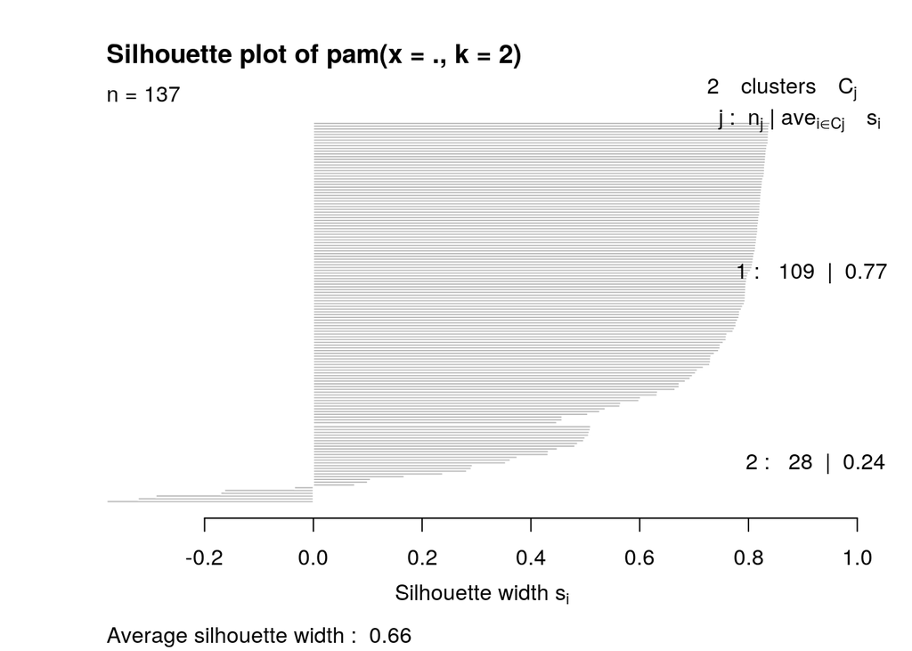

```r
plot(pam1, which = 2)
```

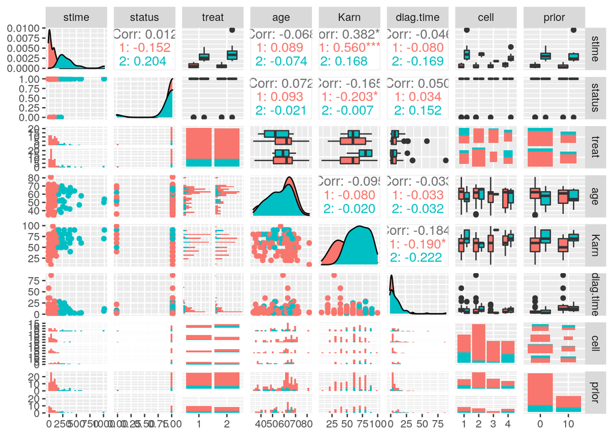

```r
pamclust <- VA %>% mutate(cluster = as.factor(pam1$clustering))

ggpairs(pamclust, columns = 1:8, aes(color = cluster))
```

The results of the clustering show that ‘stime’, which is the survival time in days since the treatment has the highest correlation with the patient’s Karnofsky score and that the correlation is 0.382. The number of clusters was decided when the silhouette width was computed in k-means and showed that 2 clusters would be the best option. When interpreting the average silhouette width and ultimately determining goodness-of-fit, we get 0.66, which means that a reasonable structure has been found.

### Dimensionality Reduction with PCA

```r
VA_nums <- VA %>% select_if(is.numeric) %>% scale()
VA_pca <- princomp(VA_nums)
names(VA_pca)
```

```
## [1] "sdev"     "loadings" "center"   "scale"    "n.obs"    "scores"   "call"
```

```r
summary(VA_pca, loadings = T)
```

```
## Importance of components:
##                          Comp.1    Comp.2    Comp.3    Comp.4    Comp.5
## Standard deviation     1.221180 1.0176846 1.0061534 0.9310400 0.7465666
## Proportion of Variance 0.300449 0.2086595 0.2039577 0.1746418 0.1122920
## Cumulative Proportion  0.300449 0.5091085 0.7130662 0.8877080 1.0000000
##
## Loadings:
##           Comp.1 Comp.2 Comp.3 Comp.4 Comp.5
## stime      0.567  0.111  0.505  0.209  0.607
## status    -0.272  0.397  0.711 -0.443 -0.258
## age       -0.223  0.741 -0.127  0.619
## Karn       0.676                0.128 -0.721
## diag.time -0.312 -0.525  0.471  0.600 -0.211
```

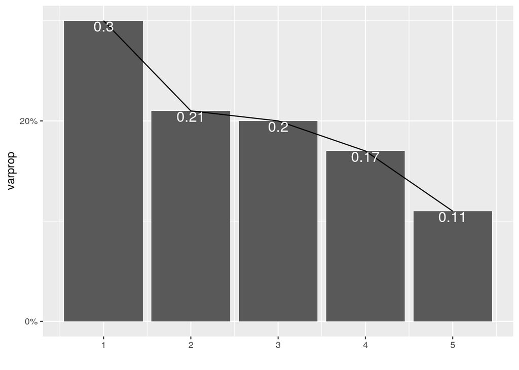

```r
eigval <- VA_pca$sdev^2
varprop = round(eigval/sum(eigval), 2)

ggplot() + geom_bar(aes(y = varprop, x = 1:5), stat = "identity") +
    xlab("") + geom_path(aes(y = varprop, x = 1:5)) + geom_text(aes(x = 1:5,
    y = varprop, label = round(varprop, 2)), vjust = 1, col = "white",
    size = 5) + scale_y_continuous(breaks = seq(0, 0.6, 0.2),
    labels = scales::percent) + scale_x_continuous(breaks = 1:10)
```

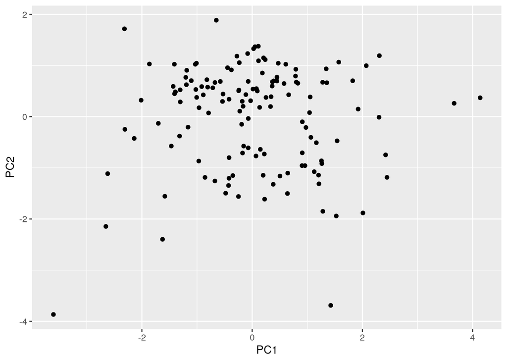

```r
VA_df <- data.frame(Name = VA$stime, PC1 = VA_pca$scores[, 1],
    PC2 = VA_pca$scores[, 2])
ggplot(VA_df, aes(PC1, PC2)) + geom_point()
```

Looking at the variance in each of the 5 numeric variables, the first PCA has the greatest variance of 0.3. When plotted onto a graph, there seems to be not a lot of relation between survival time and the PCA scores.

### Linear Classifier

```r
stime_fit <- glm(status ~ stime, data = VA, family = "binomial")
stime_score <- predict(stime_fit, type = "response")
class_diag(stime_score, VA$status, positive = 0)
```

```
##            acc sens spec    ppv     f1  ba    auc
## Metrics 0.0657    1    0 0.0657 0.1233 0.5 0.6176
```

```r
cell_fit <- glm(status ~ cell, data = VA, family = "binomial")
cell_score <- predict(cell_fit, type = "response")
class_diag(cell_score, VA$status, positive = 0)
```

```
##            acc sens spec    ppv     f1  ba    auc
## Metrics 0.0657    1    0 0.0657 0.1233 0.5 0.3702
```

```r
age_fit <- glm(status ~ age, data = VA, family = "binomial")
age_score <- predict(age_fit, type = "response")
class_diag(age_score, VA$status, positive = 0)
```

```
##            acc sens spec    ppv     f1  ba    auc
## Metrics 0.0657    1    0 0.0657 0.1233 0.5 0.4028
```

```r
Karn_fit <- glm(status ~ Karn, data = VA, family = "binomial")
Karn_score <- predict(Karn_fit, type = "response")
class_diag(Karn_score, VA$status, positive = 0)
```

```
##            acc sens spec    ppv     f1  ba    auc
## Metrics 0.0657    1    0 0.0657 0.1233 0.5 0.3212
```

```r
diag_fit <- glm(status ~ diag.time, data = VA, family = "binomial")
diag_score <- predict(diag_fit, type = "response")
class_diag(diag_score, VA$status, positive = 0)
```

```
##            acc sens spec    ppv     f1  ba    auc
## Metrics 0.0657    1    0 0.0657 0.1233 0.5 0.4544
```

```r
stime_fit2 <- glm(treat ~ stime, data = VA, family = "binomial")
stime_score2 <- predict(stime_fit2, type = "response")
class_diag(stime_score2, VA$treat, positive = 2)
```

```
##            acc   sens   spec    ppv     f1     ba    auc
## Metrics 0.4745 0.2206 0.7246 0.4412 0.2941 0.4726 0.4535
```

```r
stime_fit3 <- glm(prior ~ stime, data = VA, family = "binomial")
stime_score3 <- predict(stime_fit3, type = "response")
class_diag(stime_score3, VA$prior, positive = 10)
```

```
##            acc sens spec ppv     f1    ba    auc
## Metrics 0.7226 0.05    1   1 0.0952 0.525 0.4832
```

```r
Karn_fit2 <- glm(treat ~ Karn, data = VA, family = "binomial")
Karn_score2 <- predict(Karn_fit2, type = "response")
class_diag(Karn_score2, VA$treat, positive = 2)
```

```
##            acc   sens   spec    ppv   f1     ba    auc
## Metrics 0.5182 0.3971 0.6377 0.5192 0.45 0.5174 0.5157
```

```r
y <- VA$status
y <- factor(y, levels = c("0", "1"))
y_hat <- sample(c("0", "1"), size = length(y), replace = T)
y_hat <- factor(y_hat, levels = c("0", "1"))
table(actual = y, predicted = y_hat)
```

```
##       predicted
## actual  0  1
##      0  4  5
##      1 73 55
```

```r
set.seed(1234)
k = 10
VA <- VA %>% mutate(y = ifelse(status == "0", 0, 1))

data <- VA[sample(nrow(VA)), ]
folds <- cut(seq(1:nrow(VA)), breaks = k, labels = F)

diags <- NULL
for (i in 1:k) {
    train <- data[folds != i, ]
    test <- data[folds == i, ]
    truth <- test$y

    fit <- glm(y ~ stime, data = train, family = "binomial")

    probs <- predict(fit, newdata = test, type = "response")

    diags <- rbind(diags, class_diag(probs, truth, positive = 1))
}

summarize_all(diags, mean)
```

```
##       acc sens spec     ppv      f1  ba     auc
## 1 0.93517    1  NaN 0.93517 0.96582 NaN 0.52371
```

```r
fit <- glm(y ~ ., data = VA, family = "binomial")
coef(fit)
```

```
##   (Intercept)         stime        status        treat2           age
## -2.656607e+01  2.815986e-10  5.313214e+01  1.206210e-07 -4.520800e-09
##          Karn     diag.time         cell2         cell3         cell4
## -2.948171e-09 -7.026513e-08  2.417174e-07  1.858621e-07  2.582350e-07
##       prior10
##  6.200994e-07
```

```r
probs <- predict(fit, type = "response")
class_diag(probs, VA$y, positive = 1)  #wrong
```

```
##         acc sens spec ppv f1 ba auc
## Metrics   1    1    1   1  1  1   1
```

### Non-Parametric Classifier

```r
library(caret)
knn_fit <- knn3(factor(status == 0, levels = c("TRUE", "FALSE")) ~
    Karn, data = VA, k = 5)
y_hat_knn <- predict(knn_fit, VA)

table(truth = factor(VA$status == 0, levels = c("TRUE", "FALSE")),
    prediction = factor(y_hat_knn[, 1] > 0.5, levels = c("TRUE",
        "FALSE")))
```

```
##        prediction
## truth   TRUE FALSE
##   TRUE     0     9
##   FALSE    0   128
```

```r
class_diag(y_hat_knn[, 1], VA$status, positive = 0)
```

```
##            acc sens spec ppv  f1  ba    auc
## Metrics 0.9343    0    1 NaN NaN 0.5 0.7049
```

```r
set.seed(1234)
k = 10
data <- VA[sample(nrow(VA)), ]
folds <- cut(seq(1:nrow(VA)), breaks = k, labels = F)
diags <- NULL
for (i in 1:k) {
    train <- data[folds != i, ]
    test <- data[folds == i, ]
    truth <- test$y
    fit <- knn3(y ~ Karn, data = train)
    probs <- predict(fit, newdata = test)[, 2]
    diags <- rbind(diags, class_diag(probs, truth, positive = 0))
}
summarize_all(diags, mean)
```

```
##       acc sens spec     ppv  f1  ba     auc
## 1 0.06483  NaN    0 0.06483 NaN NaN 0.47709
```

For the nonparametric classifier, I used k-nearest-neighbors using the same variables as the linear classifier (patient status for my binary variable and the patient Karnofsky score for my numeric variable). After running the kNN, I got an AUC of 0.7049. I ran a cross-validation of the same model and got an AUC of 0.4771, which is a noticeable decrease. This shows that there are signs of overfitting in this model.

### Regression/Numeric Prediction

```r
fit <- lm(Karn ~ ., data = VA)
yhat <- predict(fit)
mean((VA$Karn - yhat)^2)
```

```
## [1] 309.0079
```

```r
set.seed(1234)
k = 5  #choose number of folds
data <- VA[sample(nrow(VA)), ]  #randomly order rows
folds <- cut(seq(1:nrow(VA)), breaks = k, labels = F)  #create folds
diags <- NULL
for (i in 1:k) {
    train <- data[folds != i, ]
    test <- data[folds == i, ]
    ## Fit linear regression model to training set
    fit <- lm(Karn ~ ., data = train)
    ## Get predictions/y-hats on test set (fold i)
    yhat <- predict(fit, newdata = test)
    ## Compute prediction error (MSE) for fold i
    diags <- mean((test$Karn - yhat)^2)
}
mean(diags)  #MSE higher in CV, not good (means overfitting)
```

```
## [1] 410.2738
```

### Python

```r
library(reticulate)
use_python("/usr/bin/python3", required = F)

conc <- "In conclusion, the big main takeaways are that the Karnofsky score is"
```

```python
conc = "somewhat related to whether the patient has gotten the standard or test drug."
print(r.conc,conc)
```

[output not shown]

In these two code chunks, I was able to share pieces of a string on R and python and eventually join them together to complete the sentence.

### Concluding Remarks

I do not have any specific conclusions with this dataset but it was interesting to look at the relationship between survival of the patient with either the type of drug or prior therapy. For future analyses, I would like to specifically look at these variables.